# Step Analysis

It is now possible to collect a large amount of data about personal movement using activity monitoring devices such as a Fitbit, Nike Fuelband, or Jawbone Up. These type of devices are part of the “quantified self” movement - a group of enthusiasts who take measurements about themselves regularly to improve their health, to find patterns in their behavior, or because they are tech geeks. But this data remains under-utilized because the raw data is hard to obtain, as well as there is a lack of statistical methods and software for processing and interpreting the data.

This report makes use of data from a personal activity monitoring device. This device collects data at 5 minute intervals through out the day. The data consists of two months of data from an anonymous individual collected during the months of October and November, 2012 and include the number of steps taken in 5 minute intervals each day.

The variables included in this dataset are:

STEPS: Number of steps taking in a 5-minute interval (missing values are coded as NA).  
DATE: The date on which the measurement was taken in YYYY-MM-DD format.  
INTERVAL: Identifier for the 5-minute interval in which measurement was taken.

The dataset is stored in a comma-separated-value (CSV) file and there are a total of 17,568 observations

## 1. Code for reading and processing the dataset

```r
all_data <- read.table("activity.csv",header=TRUE,sep = ",",stringsAsFactors=FALSE)
all_data$date <- as.POSIXct(all_data$date)
data_nona <- na.omit(all_data)
```

## 2. Histogram of the total number of steps taken each day

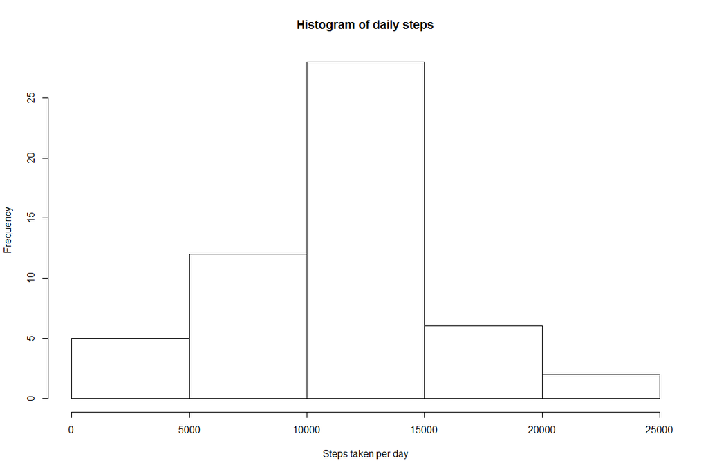

## 4. Time series plot of the average number of steps taken

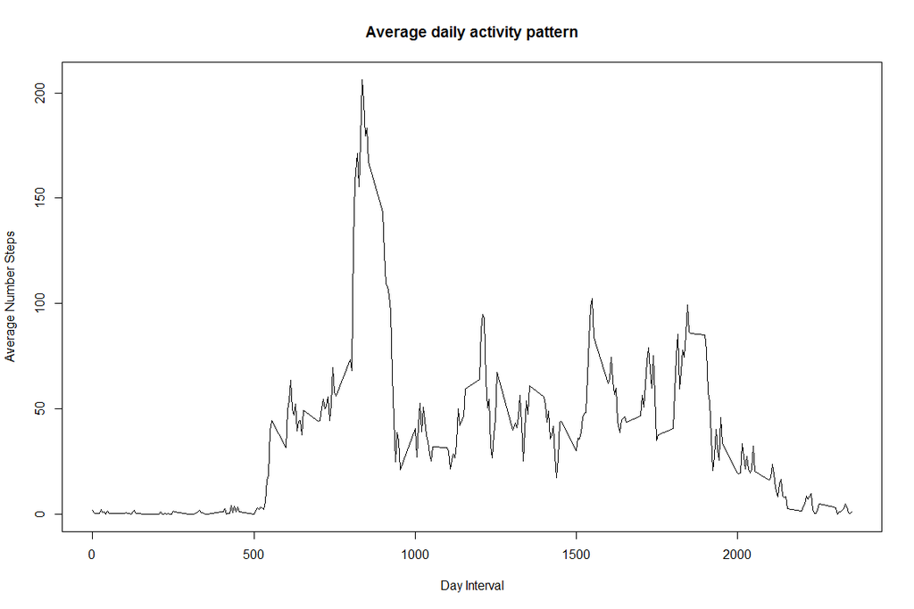

## 5. The 5-minute interval that, on average, contains the maximum number of steps

Day Interval: 835  
Avg. Number of Steps: 206.1698113

## 6. Code to describe and show a strategy for imputing missing data

Create new dataframe by imputing/applying the avg number of steps by interval of completed cases to the observations where step value is NA.

```r
imputed_data <- all_data
imputed_data2 <- transform(imputed_data, steps = ifelse(is.na(steps), ave(steps, interval, FUN = function(x) mean(x, na.rm = TRUE)), steps))
steps_by_day2 <- aggregate(steps ~ date,imputed_data2, sum)
```

## 7. Histogram of the total number of steps taken each day after missing values are imputed

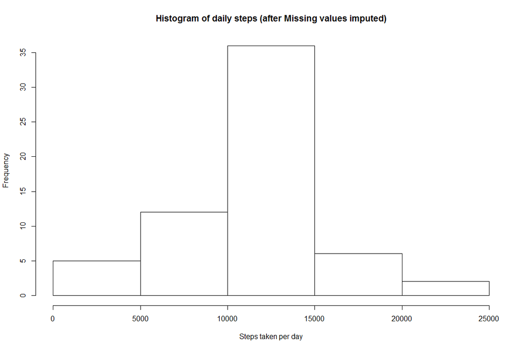